## Selection des variables explicatives

On propose ici de faire une sélection des variables explicatives en tenant profit des résultats trouvés lors de l’exploration et le traitement des données. On ne considère que les variables les plus significatives pour cette prédiction. On lance ensuite l’algorithme de l’arbre décisionnel et on recueille les résultats statistiques

```r
formula.new <- "Cote_credit ~ Solde_compte + Duree_credit_mois + Historique_credit_statut
+ But_credit + Montant_credit + Credit_demande + Epargne_statut+ Duree_emploi+ Taux_acompte + Proprietes_biens + Credit_banque "

trained.New.model <- rpart(formula=as.formula(formula.new),
                       method="class",data=data.training,control =
                         rpart.control(minsplit=20, cp=0.05))
predicted.New.model <- predict(trained.New.model, data.testing,
                           type="class")
confusionMatrix(data=predicted.New.model, reference=dep.var.test,
                positive="1")
```

[output not shown]

```r
print(trained.New.model)
```

```
## n= 750
##
## node), split, n, loss, yval, (yprob)
##       * denotes terminal node
##
## 1) root 750 216 1 (0.2880000 0.7120000)
##   2) Solde_compte=1,2 411 177 1 (0.4306569 0.5693431)
##     4) Historique_credit_statut=1 51  14 0 (0.7254902 0.2745098) *
##     5) Historique_credit_statut=2,3 360 140 1 (0.3888889 0.6111111) *
##   3) Solde_compte=3 339  39 1 (0.1150442 0.8849558) *
```

```r
print(trained.model)
```

```
## n= 750
##
## node), split, n, loss, yval, (yprob)
##       * denotes terminal node
##
## 1) root 750 216 1 (0.2880000 0.7120000)
##   2) Solde_compte=1,2 411 177 1 (0.4306569 0.5693431)
##     4) Historique_credit_statut=1 51  14 0 (0.7254902 0.2745098) *
##     5) Historique_credit_statut=2,3 360 140 1 (0.3888889 0.6111111) *
##   3) Solde_compte=3 339  39 1 (0.1150442 0.8849558) *
```

Le résultat est un peu surprenant car les statistiques sont exactement les mêmes et donc le score F1 aussi. Ceci justifie la robustesse de la méthode. Enfin, on propose de faire la réprésentation grahique d’un bout de l’arbre. ## Repérsentation graphique d’une partie de l’arbre décisionnel

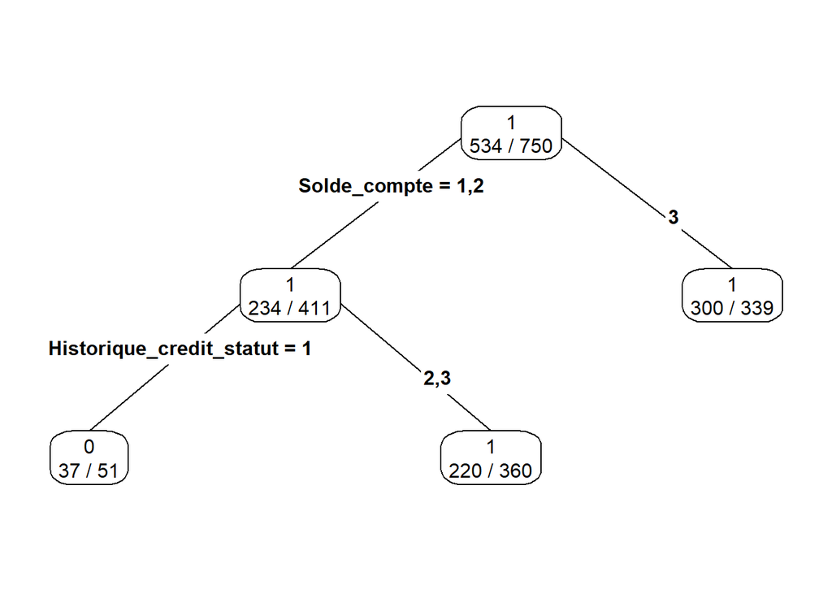

```r
par(mfrow=c(1,1))
prp(trained.model, type=4, extra=2, varlen=0, faclen=0)
```

On représente alors la courbe ROC pour évaluer la performance de ce modèle ##Représentation graphique de la courbe ROC

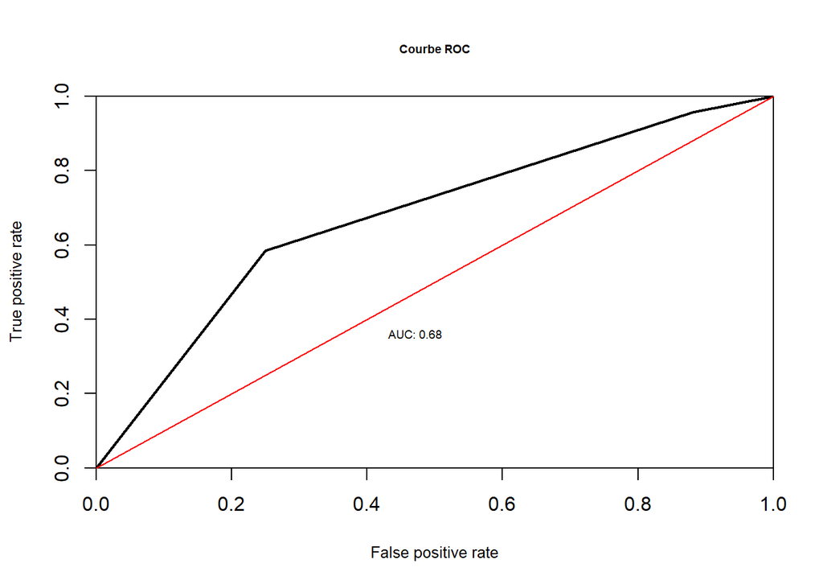

```r
plot.roc.curve <- function(predictions, title.text)
  {
  perf <- performance(predictions, "tpr", "fpr")
  plot(perf,col="black",lty=1, lwd=2,
       main=title.text, cex.main=0.6, cex.lab=0.8,xaxs="i", yaxs="i")
  abline(0,1, col="red")
  auc <- performance(predictions,"auc")
  auc <- unlist(slot(auc, "y.values"))
  auc <- round(auc,2)
  legend(0.4,0.4,legend=c(paste0("AUC: ",auc)),cex=0.6,bty = "n",box.col = "white")
}

dt.predictions <- predict(trained.model, data.testing, type="prob")
dt.prediction.values <- dt.predictions[,2]
predictions <- prediction(dt.prediction.values, dep.var.test)


plot.roc.curve(predictions, title.text="Courbe ROC")
```